# Homework 5: Supervised Learning, part 2

### Review

In the previous homework, we build a k-nearest neighbor classifier for airline delays. We also tested using GridSearchCV to find the best parameters and a basic feature selection methodology.

Despite the tweaking, we still did not get amazing results (AUROC of 0.54ish - so barely above random)

This assignment, we will:

- Try some more methods based on decision trees:
  - A single decision tree
  - Random Forest
  - Gradient-boosted Trees, using XGBoost
- Try a simple neural network
- Do a little more feature engineering/selection

and, hopefully, we will get a better result!

We will evalute our best model against our test data, which we have ignored up until now

```python
import pandas as pd

from collections import Counter
from matplotlib import pyplot as plt
from sklearn.neighbors import  KNeighborsClassifier
from sklearn.tree import DecisionTreeClassifier

from sklearn.metrics import accuracy_score, f1_score
from sklearn.metrics import precision_score, recall_score
from sklearn.metrics import classification_report, confusion_matrix, precision_recall_curve, average_precision_score, roc_curve, auc
from sklearn.metrics import roc_curve, roc_auc_score


pd.set_option('display.max_rows', 500)
pd.set_option('display.max_columns', 500)
```

```python
# For simplicity, let's all use the streamlined data set

df = pd.read_csv('streamlined_data.csv')
```

```python
# Let's inspect the data (again!)

df
```

|  | Unnamed: 0 | datetime | FL_DATE | hour | week_of_year | day_name | month_key | month_of_year | AIRLINE_CODE | ORIGIN | DEST | delay_ind | train_test_split | feature_AIRLINE_CODE_1d_delays | feature_AIRLINE_CODE_1d_avg_delays | feature_AIRLINE_CODE_1d_cnt_delays | feature_ORIGIN_1d_delays | feature_ORIGIN_1d_avg_delays | feature_ORIGIN_1d_cnt_delays | feature_DEST_1d_delays | feature_DEST_1d_avg_delays | feature_DEST_1d_cnt_delays | feature_AIRLINE_CODE_7d_delays | feature_AIRLINE_CODE_7d_avg_delays | feature_AIRLINE_CODE_7d_cnt_delays | feature_ORIGIN_7d_delays | feature_ORIGIN_7d_avg_delays | feature_ORIGIN_7d_cnt_delays | feature_DEST_7d_delays | … |
| --- | --- | --- | --- | --- | --- | --- | --- | --- | --- | --- | --- | --- | --- | --- | --- | --- | --- | --- | --- | --- | --- | --- | --- | --- | --- | --- | --- | --- | --- | --- |
| 0 | 2659802 | 2022-09-20 09:29:00 | 2022-09-20 | 9 | 38 | Tuesday | 202209 | 9 | QX | EUG | SEA | 0 | train | 11.0 | 0.333333 | 33 | 1.0 | 0.500000 | 2 | 20.0 | 0.350877 | 57 | 19.0 | 0.105556 | 180 | 1.0 | 0.071429 | 14 | 65.0 | … |
| 1 | 2859644 | 2022-12-30 19:00:00 | 2022-12-30 | 19 | 52 | Friday | 202212 | 12 | AA | HNL | DFW | 0 | train | 66.0 | 0.261905 | 252 | 3.0 | 0.176471 | 17 | 30.0 | 0.326087 | 92 | 552.0 | 0.337821 | 1634 | 39.0 | 0.293233 | 133 | 169.0 | … |
| 2 | 172100 | 2022-03-12 07:25:00 | 2022-03-12 | 7 | 10 | Saturday | 202203 | 3 | WN | ONT | PHX | 0 | train | 195.0 | 0.541667 | 360 | 1.0 | 0.090909 | 11 | 22.0 | 0.392857 | 56 | 771.0 | 0.337270 | 2286 | 6.0 | 0.157895 | 38 | 81.0 | … |
| 3 | 1359913 | 2022-04-21 19:50:00 | 2022-04-21 | 19 | 16 | Thursday | 202204 | 4 | AS | SEA | SNA | 1 | train | 9.0 | 0.115385 | 78 | 5.0 | 0.090909 | 55 | 1.0 | 0.076923 | 13 | 75.0 | 0.166667 | 450 | 48.0 | 0.149068 | 322 | 13.0 | … |
| 4 | 1109043 | 2022-12-08 19:21:00 | 2022-12-08 | 19 | 49 | Thursday | 202212 | 12 | DL | ATL | MIA | 0 | train | 33.0 | 0.133603 | 247 | 10.0 | 0.112360 | 89 | 8.0 | 0.347826 | 23 | 220.0 | 0.120680 | 1823 | 70.0 | 0.107034 | 654 | 32.0 | … |
| ... | ... | ... | ... | ... | ... | ... | ... | ... | ... | ... | ... | ... | ... | ... | ... | ... | ... | ... | ... | ... | ... | ... | ... | ... | ... | ... | ... | ... | ... | … |
| 249995 | 2894199 | 2023-02-19 14:44:00 | 2023-02-19 | 14 | 7 | Sunday | 202302 | 2 | AA | DFW | PBI | 0 | test | 27.0 | 0.133005 | 203 | 7.0 | 0.106061 | 66 | 1.0 | 0.090909 | 11 | 329.0 | 0.186508 | 1764 | 94.0 | 0.182171 | 516 | 8.0 | … |
| 249996 | 2271611 | 2023-04-29 06:15:00 | 2023-04-29 | 6 | 17 | Saturday | 202304 | 4 | DL | SYR | ATL | 0 | test | 50.0 | 0.191571 | 261 | 0.0 | 0.000000 | 6 | 19.0 | 0.228916 | 83 | 266.0 | 0.143165 | 1858 | 4.0 | 0.153846 | 26 | 104.0 | … |
| 249997 | 1786343 | 2023-08-25 08:00:00 | 2023-08-25 | 8 | 34 | Friday | 202308 | 8 | HA | HNL | OGG | 0 | test | 1.0 | 0.052632 | 19 | 1.0 | 0.058824 | 17 | 1.0 | 0.083333 | 12 | 19.0 | 0.126667 | 150 | 20.0 | 0.149254 | 134 | 4.0 | … |
| 249998 | 1164942 | 2023-07-24 08:56:00 | 2023-07-24 | 8 | 30 | Monday | 202307 | 7 | AA | DFW | SMF | 0 | test | 113.0 | 0.393728 | 287 | 26.0 | 0.265306 | 98 | 2.0 | 0.250000 | 8 | 622.0 | 0.325825 | 1909 | 174.0 | 0.281553 | 618 | 18.0 | … |
| 249999 | 1183682 | 2023-01-30 11:16:00 | 2023-01-30 | 11 | 5 | Monday | 202301 | 1 | OO | MSP | FAR | 0 | test | 48.0 | 0.300000 | 160 | 7.0 | 0.184211 | 38 | 1.0 | 0.250000 | 4 | 202.0 | 0.178445 | 1132 | 43.0 | 0.179167 | 240 | 6.0 | … |

250000 rows × 49 columns

## Data Prep

I am going to include some data prep here, just so we can move on to the new material and you all did versions of this last time.

```python
df.train_test_split.value_counts()
```

```
train_test_split
train    200000
test      50000
Name: count, dtype: int64
```

```python
from sklearn.preprocessing import StandardScaler

# We are going to go ahead and impute 0s for all null values.
df = df.fillna(0)

training_df = df[df['train_test_split'] == 'train']
test_df = df[df['train_test_split'] =='test']

features = [i for i in df.columns if 'feature' in i ]

X_train = training_df[features]
X_test = test_df[features]

scaler = StandardScaler()
scaler.fit(X_train)

X_train = scaler.transform(X_train)
X_test = scaler.transform(X_test)


y_train = training_df['delay_ind']
y_test = test_df['delay_ind']


print(X_train.shape, X_test.shape)
```

```
(200000, 36) (50000, 36)
```

# Question 1: Decision Tree Classifier

**Question 1a:** Using the training data, build a decision tree with `max_depth = 3` and measure the precision, recall, f1_score and AUROC on the test data. You should use `sklearn.tree.DecisionTreeClassifier`

**Question 1b:** Using the model, visualize what the ree is doing using the `plot_tree` function. Try to make the plot readable, with feature names (not index values) and of legible size [docs here](https://scikit-learn.org/1.5/modules/generated/sklearn.tree.plot_tree.html)

**Question 1c:** Redo 1a and 1b, but with `max_depth = 7`. How does the performance change? Is the tree understandable?

```python
# Question 1a

dt_clf_depth3 = DecisionTreeClassifier(max_depth=3)
dt_clf_depth3.fit(X_train, y_train)

y_pred = dt_clf_depth3.predict(X_test)
y_pred_proba = dt_clf_depth3.predict_proba(X_test)[:, 1]

# performance metrics
precision = precision_score(y_test, y_pred)
recall = recall_score(y_test, y_pred)
f1 = f1_score(y_test, y_pred)
auroc = roc_auc_score(y_test, y_pred_proba)

print(f"Precision: {precision:.2f}")
print(f"Recall: {recall:.2f}")
print(f"F1 Score: {f1:.2f}")
print(f"AUROC: {auroc:.2f}")
```

```
Precision: 0.00
Recall: 0.00
F1 Score: 0.00
AUROC: 0.62
```

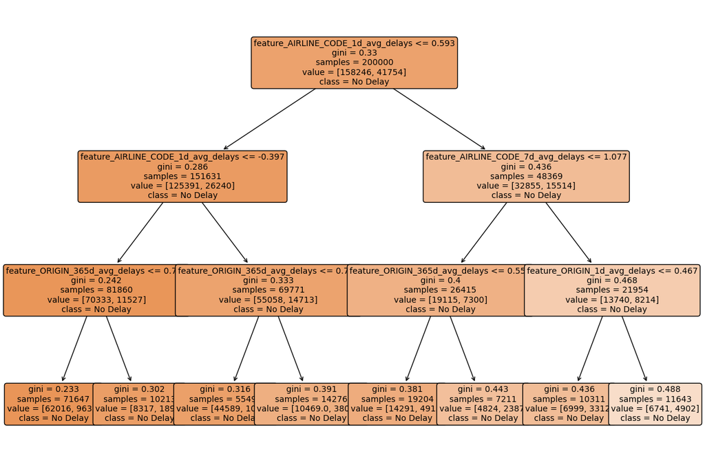

```python
# Question 1b

from sklearn.tree import plot_tree

plt.figure(figsize=(15, 10))
plot_tree(
    dt_clf_depth3,
    feature_names=features,
    class_names=['No Delay', 'Delay'],
    filled=True,
    rounded=True,
    fontsize=10
)
plt.show()
```

```python
# Question 1c

dt_clf_depth7 = DecisionTreeClassifier(max_depth=7)
dt_clf_depth7.fit(X_train, y_train)

y_pred_depth7 = dt_clf_depth7.predict(X_test)
y_pred_proba_depth7 = dt_clf_depth7.predict_proba(X_test)[:, 1]

# performance metrics
precision_depth7 = precision_score(y_test, y_pred_depth7)
recall_depth7 = recall_score(y_test, y_pred_depth7)
f1_depth7 = f1_score(y_test, y_pred_depth7)
auroc_depth7 = roc_auc_score(y_test, y_pred_proba_depth7)

print(f"Precision (depth=7): {precision_depth7:.2f}")
print(f"Recall (depth=7): {recall_depth7:.2f}")
print(f"F1 Score (depth=7): {f1_depth7:.2f}")
print(f"AUROC (depth=7): {auroc_depth7:.2f}")
```

```
Precision (depth=7): 0.33
Recall (depth=7): 0.06
F1 Score (depth=7): 0.10
AUROC (depth=7): 0.62
```

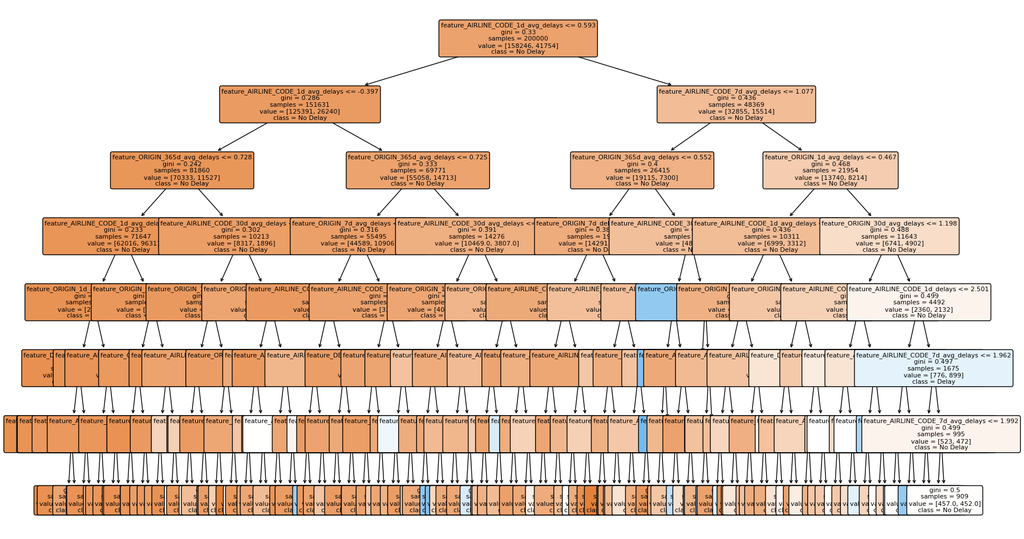

```python
plt.figure(figsize=(20, 12))
plot_tree(
    dt_clf_depth7,
    feature_names=features,
    class_names=['No Delay', 'Delay'],
    filled=True,
    rounded=True,
    fontsize=8
)
plt.show()
```

# Question 2: Random Forest and XGBoost

**Question 2a:** Using sklearn.ensemble.RandomForestClassifier, train a random forest on your training data using the following parameters: `max_depth=5, n_estimators=50, min_samples_leaf=5, class_weight = {0:1, 1:5}` Once again, measure precision, recall, f1_score and AUROC on the test data. Is it better or worse than your decision tree?

**Question 2b:** Do the same, with an XGBoost model. (see the [documentation here](https://xgboost.readthedocs.io/en/stable/python/python_intro.html) on hte python version, including installation and links to the scikit-learn estimator interface). Use `XGBClassifier` as your classifier. Note: XGBoost does not have `min_samples_leaf` or `class_weight parameter`. `scale_pos_weight`, however, plays the same role as class_weight, but only needs the weight of the positive class. For the time being, ignore the `min_samples_leaf` parameter, but set the `learning_rate` = 0.01 and `scale_pos_weight`=5

**Question 2c:** What model looks the best so far?

**NOTE:** An additional note on xgboost: you may get a warning about running a 32-bit python on a 64-bit machine. This is most likely due to not having openmp installed. Installing xgboost via conda (rather than pip) may solve this issue. Or, you may need to install openmp (possibly with python package llvm-openmp

```python
# Question 2a

from sklearn.ensemble import RandomForestClassifier

rf_clf = RandomForestClassifier(max_depth=5, n_estimators=50, min_samples_leaf=5, class_weight={0: 1, 1: 5}, random_state=42)
rf_clf.fit(X_train, y_train)

y_pred_rf = rf_clf.predict(X_test)
y_pred_proba_rf = rf_clf.predict_proba(X_test)[:, 1]

# performance metrics
precision_rf = precision_score(y_test, y_pred_rf)
recall_rf = recall_score(y_test, y_pred_rf)
f1_rf = f1_score(y_test, y_pred_rf)
auroc_rf = roc_auc_score(y_test, y_pred_proba_rf)

print(f"Random Forest - Precision: {precision_rf:.2f}")
print(f"Random Forest - Recall: {recall_rf:.2f}")
print(f"Random Forest - F1 Score: {f1_rf:.2f}")
print(f"Random Forest - AUROC: {auroc_rf:.2f}")
```

```
Random Forest - Precision: 0.25
Random Forest - Recall: 0.87
Random Forest - F1 Score: 0.39
Random Forest - AUROC: 0.64
```

```python
# Question 2b

from xgboost import XGBClassifier

xgb_clf = XGBClassifier(learning_rate=0.01, scale_pos_weight=5, random_state=42)
xgb_clf.fit(X_train, y_train)

y_pred_xgb = xgb_clf.predict(X_test)
y_pred_proba_xgb = xgb_clf.predict_proba(X_test)[:, 1]

# performance metrics
precision_xgb = precision_score(y_test, y_pred_xgb)
recall_xgb = recall_score(y_test, y_pred_xgb)
f1_xgb = f1_score(y_test, y_pred_xgb)
auroc_xgb = roc_auc_score(y_test, y_pred_proba_xgb)

print(f"XGBoost - Precision: {precision_xgb:.2f}")
print(f"XGBoost - Recall: {recall_xgb:.2f}")
print(f"XGBoost - F1 Score: {f1_xgb:.2f}")
print(f"XGBoost - AUROC: {auroc_xgb:.2f}")
```

```
XGBoost - Precision: 0.25
XGBoost - Recall: 0.91
XGBoost - F1 Score: 0.39
XGBoost - AUROC: 0.64
```

```python
# Question 2c

print("Decision Tree (max_depth=3):")
print(f"Precision: {precision:.2f}, Recall: {recall:.2f}, F1 Score: {f1:.2f}, AUROC: {auroc:.2f}\n")

print("Decision Tree (max_depth=7):")
print(f"Precision: {precision_depth7:.2f}, Recall: {recall_depth7:.2f}, F1 Score: {f1_depth7:.2f}, AUROC: {auroc_depth7:.2f}\n")

print("Random Forest:")
print(f"Precision: {precision_rf:.2f}, Recall: {recall_rf:.2f}, F1 Score: {f1_rf:.2f}, AUROC: {auroc_rf:.2f}\n")

print("XGBoost:")
print(f"Precision: {precision_xgb:.2f}, Recall: {recall_xgb:.2f}, F1 Score: {f1_xgb:.2f}, AUROC: {auroc_xgb:.2f}\n")
```

```
Decision Tree (max_depth=3):
Precision: 0.00, Recall: 0.00, F1 Score: 0.00, AUROC: 0.62

Decision Tree (max_depth=7):
Precision: 0.33, Recall: 0.06, F1 Score: 0.10, AUROC: 0.62

Random Forest:
Precision: 0.25, Recall: 0.87, F1 Score: 0.39, AUROC: 0.64

XGBoost:
Precision: 0.25, Recall: 0.91, F1 Score: 0.39, AUROC: 0.64
```

# Creating a pipeline

So, we now have 4 different models we have tested: KNN, DecisionTree, RandomForest, and gradient-boosted machine (XGBoost). Last week, we also tried training with and without feature selection. In training these, we have created a fair amount of redundant code, although last week we did streamline some things with the GridSearchCV. Or, put another way, there have been a lot of different `.fit` statements!

One way to try to deal with this is to create a "pipeline" that stitches things together and makes them more repeatable, lowers the chances for errors and so on. There are many different ways you can do this in practice, including production-oriented systems like [Apache Airflow](https://airflow.apache.org/) or [Dagster](https://dagster.io/)

We will see a little about how this works in the model-training specific parts of our code using [scikit-learn pipelines](https://scikit-learn.org/1.5/modules/generated/sklearn.pipeline.Pipeline.html).

I am going to set up a basic version here, but you will then use it to do a grid-search over our single DecisionTree, RandomForest, and XGBoost.

I am going to use an example from this [stack overflow question](https://stackoverflow.com/questions/48507651/multiple-classification-models-in-a-scikit-pipeline-python)

```python
from sklearn.base import BaseEstimator
class ClfSwitcher(BaseEstimator):
    def __init__(
        self,
        estimator = DecisionTreeClassifier(),
    ):
        """
        A Custom BaseEstimator that can switch between classifiers.
        :param estimator: sklearn object - The classifier
        """

        self.estimator = estimator


    def fit(self, X, y=None, **kwargs):
        self.estimator.fit(X, y, **kwargs)
        return self


    def predict(self, X, y=None):
        return self.estimator.predict(X)


    def predict_proba(self, X):
        return self.estimator.predict_proba(X)


    def score(self, X, y):
        return self.estimator.score(X, y)
```

```python
from sklearn.pipeline import Pipeline
from sklearn.neighbors import  KNeighborsClassifier
from sklearn.metrics import make_scorer, precision_score, recall_score, f1_score, roc_auc_score
from sklearn.model_selection import GridSearchCV


# In a pipeline, you create a list of steps. Each of these steps that can take hyperparameters
# can be set up that way so that you can do a grid search (or some other search) over them.
# The output of the pipeline is like a model itself, which, when `transform` or `predict` is called
# it will run the entire pipeline of steps (scaling, null handling, feature selection, model-scoring, etc.
# that you trained it to do. This makes it much easier to train and compare many hundreds of
# possible variations of everything without much duplicated code.

pipeline = Pipeline([
    ('scaler', StandardScaler()),
    ('clf', ClfSwitcher()),
])

parameters = [
    {
        'clf__estimator': [KNeighborsClassifier()],
        'clf__estimator__n_neighbors': [3,5,7],
    },

    {
        'clf__estimator': [DecisionTreeClassifier()],
        'clf__estimator__max_depth': [3,5,7],
        'clf__estimator__min_samples_leaf': [5,10],
        'clf__estimator__class_weight': [{0:1, 1:3}, {0:1, 1:5}, {0:1, 1:7}]
    }]

# Define custom scoring metrics
scoring = {
    'precision': make_scorer(precision_score, average='binary'),
    'recall': make_scorer(recall_score, average='binary'),
    'f1_score': make_scorer(f1_score, average='binary'),
    'auroc': make_scorer(roc_auc_score, average='weighted')
}

gscv = GridSearchCV(pipeline, parameters, cv=5, n_jobs=-1, refit='auroc', verbose=3, scoring=scoring)

gscv.fit(X_train, y_train)

#cv_results = cross_validate(pipeline, X_train, y_train, cv=5, scoring=scoring)
```

```
Fitting 5 folds for each of 21 candidates, totalling 105 fits
```

```
GridSearchCV(cv=5,
             estimator=Pipeline(steps=[('scaler', StandardScaler()),
                                       ('clf', ClfSwitcher())]),
             n_jobs=-1,
             param_grid=[{'clf__estimator': [KNeighborsClassifier()],
                          'clf__estimator__n_neighbors': [3, 5, 7]},
                         {'clf__estimator': [DecisionTreeClassifier()],
                          'clf__estimator__class_weight': [{0: 1, 1: 3},
                                                           {0: 1, 1: 5},
                                                           {0: 1, 1: 7}],
                          'clf__estimator__max_depth': [3, 5, 7],
                          'clf__...10]}],
             refit='auroc',
             scoring={'auroc': make_scorer(roc_auc_score, response_method='predict', average=weighted),
                      'f1_score': make_scorer(f1_score, response_method='predict', average=binary),
                      'precision': make_scorer(precision_score, response_method='predict', average=binary),
                      'recall': make_scorer(recall_score, response_method='predict', average=binary)},
             verbose=3)
```

```python
pd.DataFrame(gscv.cv_results_).sort_values('rank_test_auroc')
```

|  | mean_fit_time | std_fit_time | mean_score_time | std_score_time | param_clf__estimator | param_clf__estimator__n_neighbors | param_clf__estimator__class_weight | param_clf__estimator__max_depth | param_clf__estimator__min_samples_leaf | params | split0_test_precision | split1_test_precision | split2_test_precision | split3_test_precision | split4_test_precision | mean_test_precision | std_test_precision | rank_test_precision | split0_test_recall | split1_test_recall | split2_test_recall | split3_test_recall | split4_test_recall | mean_test_recall | std_test_recall | rank_test_recall | split0_test_f1_score | split1_test_f1_score | split2_test_f1_score | … |
| --- | --- | --- | --- | --- | --- | --- | --- | --- | --- | --- | --- | --- | --- | --- | --- | --- | --- | --- | --- | --- | --- | --- | --- | --- | --- | --- | --- | --- | --- | --- |
| 7 | 3.021563 | 0.291114 | 0.041966 | 0.003268 | DecisionTreeClassifier() | NaN | {0: 1, 1: 3} | 7 | 5 | {'clf__estimator': DecisionTreeClassifier(), '... | 0.329903 | 0.326822 | 0.320283 | 0.329306 | 0.317071 | 0.324677 | 0.005109 | 7 | 0.405862 | 0.408645 | 0.417758 | 0.407390 | 0.403388 | 0.408608 | 0.004899 | 13 | 0.363961 | 0.363182 | 0.362584 | … |
| 8 | 3.406664 | 0.435505 | 0.047639 | 0.010386 | DecisionTreeClassifier() | NaN | {0: 1, 1: 3} | 7 | 10 | {'clf__estimator': DecisionTreeClassifier(), '... | 0.329680 | 0.326568 | 0.320312 | 0.329244 | 0.317145 | 0.324590 | 0.005004 | 8 | 0.405510 | 0.408405 | 0.417758 | 0.407509 | 0.403751 | 0.408587 | 0.004861 | 14 | 0.363684 | 0.362930 | 0.362603 | … |
| 13 | 2.856124 | 0.318162 | 0.038615 | 0.005109 | DecisionTreeClassifier() | NaN | {0: 1, 1: 5} | 7 | 5 | {'clf__estimator': DecisionTreeClassifier(), '... | 0.262000 | 0.263442 | 0.254698 | 0.268513 | 0.263146 | 0.262360 | 0.004438 | 10 | 0.745487 | 0.694564 | 0.718462 | 0.674638 | 0.691470 | 0.704924 | 0.024634 | 11 | 0.387732 | 0.381997 | 0.376075 | … |
| 14 | 2.856254 | 0.366059 | 0.047154 | 0.006673 | DecisionTreeClassifier() | NaN | {0: 1, 1: 5} | 7 | 10 | {'clf__estimator': DecisionTreeClassifier(), '... | 0.261926 | 0.263595 | 0.254753 | 0.268419 | 0.263100 | 0.262359 | 0.004401 | 11 | 0.745369 | 0.694684 | 0.718462 | 0.673921 | 0.691349 | 0.704757 | 0.024776 | 12 | 0.387636 | 0.382176 | 0.376135 | … |
| 5 | 2.195540 | 0.032545 | 0.042226 | 0.003042 | DecisionTreeClassifier() | NaN | {0: 1, 1: 3} | 5 | 5 | {'clf__estimator': DecisionTreeClassifier(), '... | 0.333501 | 0.336655 | 0.323532 | 0.337758 | 0.309157 | 0.328121 | 0.010727 | 5 | 0.389332 | 0.360034 | 0.403081 | 0.371159 | 0.424440 | 0.389609 | 0.022847 | 15 | 0.359260 | 0.347952 | 0.358952 | … |
| 6 | 2.120070 | 0.160445 | 0.039337 | 0.007399 | DecisionTreeClassifier() | NaN | {0: 1, 1: 3} | 5 | 10 | {'clf__estimator': DecisionTreeClassifier(), '... | 0.333501 | 0.336655 | 0.323532 | 0.337758 | 0.309157 | 0.328121 | 0.010727 | 5 | 0.389332 | 0.360034 | 0.403081 | 0.371159 | 0.424440 | 0.389609 | 0.022847 | 15 | 0.359260 | 0.347952 | 0.358952 | … |
| 12 | 2.079400 | 0.225561 | 0.040144 | 0.009121 | DecisionTreeClassifier() | NaN | {0: 1, 1: 5} | 5 | 10 | {'clf__estimator': DecisionTreeClassifier(), '... | 0.258386 | 0.263677 | 0.243729 | 0.245300 | 0.256579 | 0.253534 | 0.007741 | 12 | 0.759437 | 0.688458 | 0.783721 | 0.792658 | 0.727889 | 0.750433 | 0.038266 | 9 | 0.385584 | 0.381312 | 0.371824 | … |
| 11 | 2.206775 | 0.279420 | 0.035932 | 0.005529 | DecisionTreeClassifier() | NaN | {0: 1, 1: 5} | 5 | 5 | {'clf__estimator': DecisionTreeClassifier(), '... | 0.258386 | 0.263677 | 0.243729 | 0.245300 | 0.256579 | 0.253534 | 0.007741 | 12 | 0.759437 | 0.688458 | 0.783721 | 0.792658 | 0.727889 | 0.750433 | 0.038266 | 9 | 0.385584 | 0.381312 | 0.371824 | … |
| 3 | 1.351235 | 0.030633 | 0.039779 | 0.001792 | DecisionTreeClassifier() | NaN | {0: 1, 1: 3} | 3 | 5 | {'clf__estimator': DecisionTreeClassifier(), '... | 0.332466 | 0.326203 | 0.327003 | 0.339215 | 0.334515 | 0.331880 | 0.004839 | 2 | 0.374326 | 0.359674 | 0.352984 | 0.326438 | 0.308167 | 0.344318 | 0.023824 | 17 | 0.352156 | 0.342122 | 0.339497 | … |
| 4 | 1.335404 | 0.141032 | 0.037469 | 0.006264 | DecisionTreeClassifier() | NaN | {0: 1, 1: 3} | 3 | 10 | {'clf__estimator': DecisionTreeClassifier(), '... | 0.332466 | 0.326203 | 0.327003 | 0.339215 | 0.334515 | 0.331880 | 0.004839 | 2 | 0.374326 | 0.359674 | 0.352984 | 0.326438 | 0.308167 | 0.344318 | 0.023824 | 17 | 0.352156 | 0.342122 | 0.339497 | … |
| 10 | 1.373066 | 0.057835 | 0.040355 | 0.003957 | DecisionTreeClassifier() | NaN | {0: 1, 1: 5} | 3 | 10 | {'clf__estimator': DecisionTreeClassifier(), '... | 0.253232 | 0.246417 | 0.243193 | 0.245416 | 0.243778 | 0.246407 | 0.003600 | 14 | 0.792145 | 0.780172 | 0.780082 | 0.785842 | 0.783303 | 0.784309 | 0.004466 | 7 | 0.383779 | 0.374537 | 0.370791 | … |
| 9 | 1.497287 | 0.097459 | 0.040563 | 0.003810 | DecisionTreeClassifier() | NaN | {0: 1, 1: 5} | 3 | 5 | {'clf__estimator': DecisionTreeClassifier(), '... | 0.253232 | 0.246417 | 0.243193 | 0.245416 | 0.243778 | 0.246407 | 0.003600 | 14 | 0.792145 | 0.780172 | 0.780082 | 0.785842 | 0.783303 | 0.784309 | 0.004466 | 7 | 0.383779 | 0.374537 | 0.370791 | … |
| 20 | 2.833746 | 0.091160 | 0.030569 | 0.000611 | DecisionTreeClassifier() | NaN | {0: 1, 1: 7} | 7 | 10 | {'clf__estimator': DecisionTreeClassifier(), '... | 0.229070 | 0.226693 | 0.226171 | 0.226301 | 0.224325 | 0.226512 | 0.001518 | 16 | 0.916413 | 0.906011 | 0.891679 | 0.894894 | 0.896431 | 0.901085 | 0.009030 | 5 | 0.366522 | 0.362647 | 0.360821 | … |
| 19 | 3.310563 | 0.241698 | 0.032730 | 0.002341 | DecisionTreeClassifier() | NaN | {0: 1, 1: 7} | 7 | 5 | {'clf__estimator': DecisionTreeClassifier(), '... | 0.229049 | 0.226703 | 0.226110 | 0.226176 | 0.224319 | 0.226472 | 0.001520 | 17 | 0.916413 | 0.905891 | 0.891194 | 0.894535 | 0.896189 | 0.900844 | 0.009192 | 6 | 0.366496 | 0.362652 | 0.360704 | … |
| 15 | 1.509432 | 0.113982 | 0.044026 | 0.008006 | DecisionTreeClassifier() | NaN | {0: 1, 1: 7} | 3 | 5 | {'clf__estimator': DecisionTreeClassifier(), '... | 0.225565 | 0.221364 | 0.222345 | 0.233590 | 0.222564 | 0.225086 | 0.004478 | 18 | 0.933411 | 0.930196 | 0.906477 | 0.856989 | 0.909861 | 0.907387 | 0.027366 | 3 | 0.363329 | 0.357623 | 0.357098 | … |
| 16 | 1.446473 | 0.114933 | 0.044820 | 0.009950 | DecisionTreeClassifier() | NaN | {0: 1, 1: 7} | 3 | 10 | {'clf__estimator': DecisionTreeClassifier(), '... | 0.225565 | 0.221364 | 0.222345 | 0.233590 | 0.222564 | 0.225086 | 0.004478 | 18 | 0.933411 | 0.930196 | 0.906477 | 0.856989 | 0.909861 | 0.907387 | 0.027366 | 3 | 0.363329 | 0.357623 | 0.357098 | … |
| 17 | 2.305766 | 0.052038 | 0.045631 | 0.005530 | DecisionTreeClassifier() | NaN | {0: 1, 1: 7} | 5 | 5 | {'clf__estimator': DecisionTreeClassifier(), '... | 0.226232 | 0.221009 | 0.224667 | 0.224254 | 0.222737 | 0.223780 | 0.001777 | 20 | 0.931184 | 0.935824 | 0.896652 | 0.914983 | 0.913370 | 0.918402 | 0.013978 | 1 | 0.364024 | 0.357573 | 0.359306 | … |
| 18 | 2.358871 | 0.077512 | 0.041977 | 0.004841 | DecisionTreeClassifier() | NaN | {0: 1, 1: 7} | 5 | 10 | {'clf__estimator': DecisionTreeClassifier(), '... | 0.226232 | 0.221009 | 0.224667 | 0.224254 | 0.222737 | 0.223780 | 0.001777 | 20 | 0.931184 | 0.935824 | 0.896652 | 0.914983 | 0.913370 | 0.918402 | 0.013978 | 1 | 0.364024 | 0.357573 | 0.359306 | … |
| 0 | 0.104712 | 0.022477 | 27.848077 | 2.395043 | KNeighborsClassifier() | 3 | NaN | NaN | NaN | {'clf__estimator': KNeighborsClassifier(), 'cl... | 0.308832 | 0.298883 | 0.294594 | 0.296609 | 0.293181 | 0.298420 | 0.005550 | 9 | 0.178312 | 0.176245 | 0.176492 | 0.180916 | 0.180520 | 0.178497 | 0.001953 | 19 | 0.226087 | 0.221737 | 0.220739 | … |
| 1 | 0.112546 | 0.021242 | 27.510207 | 2.265844 | KNeighborsClassifier() | 5 | NaN | NaN | NaN | {'clf__estimator': KNeighborsClassifier(), 'cl... | 0.332380 | 0.328491 | 0.324691 | 0.329465 | 0.325812 | 0.328168 | 0.002727 | 4 | 0.136225 | 0.132663 | 0.133673 | 0.139185 | 0.143255 | 0.137000 | 0.003857 | 20 | 0.193248 | 0.188998 | 0.189380 | … |
| 2 | 0.060156 | 0.005991 | 29.494392 | 0.093964 | KNeighborsClassifier() | 7 | NaN | NaN | NaN | {'clf__estimator': KNeighborsClassifier(), 'cl... | 0.360447 | 0.350313 | 0.342901 | 0.351803 | 0.360251 | 0.353143 | 0.006612 | 1 | 0.109613 | 0.107040 | 0.108685 | 0.110845 | 0.118209 | 0.110879 | 0.003870 | 21 | 0.168105 | 0.163977 | 0.165055 | … |

### Question 3: Grid Search

Now! We can try training a large number of models using our pipeline. You will need to take my example pipeline and modify it, making it your own.

I would like you to include the following models and think about the listed parameters and choose some number of values of each

- DecisionTreeClassifier: max_depth, class_weight, min_samples_leaf
- RandomForestClassifier: n_estimators, max_depth, class_weight, min_samples_leaf,
- XGBoost: n_estimators, max_depth, scale_pos_weight, alpha, learning_rate (try some very small values!), colsample_bytree, subsample,
- MLPClassifier: hidden_layer_sizes, activation, learning_rate

**Tip**: this could be very slow, as you will be training many different models. Look at the `n_jobs` parameter - it may allow you to speed this up significantly (setting `n_jobs=-1` will try to use all cores on your machine) Also, look at the `verbose` setting to print more out along the way when it is set higher than 3

**Question 3a**: train the best model you can!

**Quesiton 3b**: Run the model and see the performance on the test set! Try calculating both the numbers, as well as the plots of precision/recall and ROC

```python
# Question 3a

from sklearn.neural_network import MLPClassifier

# Update the parameters for the new classifiers
parameters = [
    {
        'clf__estimator': [DecisionTreeClassifier()],
        'clf__estimator__max_depth': [3, 5, 7],
        'clf__estimator__min_samples_leaf': [5, 10],
        'clf__estimator__class_weight': [{0:1, 1:3}, {0:1, 1:5}, {0:1, 1:7}]
    },
    {
        'clf__estimator': [RandomForestClassifier()],
        'clf__estimator__n_estimators': [50, 100],
        'clf__estimator__max_depth': [5, 7, 10],
        'clf__estimator__min_samples_leaf': [5, 10],
        'clf__estimator__class_weight': [{0:1, 1:3}, {0:1, 1:5}]
    },
    {
        'clf__estimator': [XGBClassifier()],
        'clf__estimator__n_estimators': [50, 100],
        'clf__estimator__max_depth': [3, 5, 7],
        'clf__estimator__scale_pos_weight': [3, 5],
        'clf__estimator__alpha': [0, 0.01, 0.1],
        'clf__estimator__learning_rate': [0.01, 0.1],
        'clf__estimator__colsample_bytree': [0.5, 0.8],
        'clf__estimator__subsample': [0.5, 0.8]
    },
    {
        'clf__estimator': [MLPClassifier(max_iter=1000)],
        'clf__estimator__hidden_layer_sizes': [(50,), (100,), (50, 50)],
        'clf__estimator__activation': ['tanh', 'relu'],
        'clf__estimator__learning_rate': ['constant', 'adaptive']
    }
]

# custom scoring metrics
scoring = {
    'precision': make_scorer(precision_score, average='binary'),
    'recall': make_scorer(recall_score, average='binary'),
    'f1_score': make_scorer(f1_score, average='binary'),
    'auroc': make_scorer(roc_auc_score, average='weighted')
}

gscv = GridSearchCV(pipeline, parameters, cv=5, n_jobs=-1, refit='auroc', verbose=3, scoring=scoring)

gscv.fit(X_train, y_train)

print("Best parameters found: ", gscv.best_params_)
print("Best AUROC score: ", gscv.best_score_)
```

[output not shown]

[output cut: 77 more lines]

[output not shown]

[output cut: 13472 more lines]

```
Classification Report:
               precision    recall  f1-score   support

           0       0.85      0.38      0.53     38816
           1       0.27      0.78      0.39     11184

    accuracy                           0.47     50000
   macro avg       0.56      0.58      0.46     50000
weighted avg       0.72      0.47      0.50     50000

Confusion Matrix:
 [[14767 24049]
 [ 2513  8671]]
```

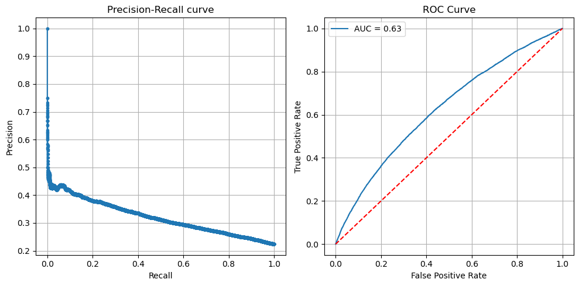

```python
# Question 3b

best_model = gscv.best_estimator_

y_pred = best_model.predict(X_test)
y_proba = best_model.predict_proba(X_test)[:, 1]  # Probability estimates for the positive class

print("Classification Report:\n", classification_report(y_test, y_pred))

# confusion matrix
cm = confusion_matrix(y_test, y_pred)
print("Confusion Matrix:\n", cm)

# Precision-Recall curve
precision, recall, _ = precision_recall_curve(y_test, y_proba)

# ROC curve
fpr, tpr, thresholds = roc_curve(y_test, y_proba)
roc_auc = auc(fpr, tpr)

# Precision-Recall curve
plt.figure(figsize=(10, 5))
plt.subplot(1, 2, 1)
plt.plot(recall, precision, marker='.')
plt.title('Precision-Recall curve')
plt.xlabel('Recall')
plt.ylabel('Precision')
plt.grid()

# ROC curve
plt.subplot(1, 2, 2)
plt.plot(fpr, tpr, label=f'AUC = {roc_auc:.2f}')
plt.plot([0, 1], [0, 1], 'r--')  # Diagonal line representing random classifier
plt.xlabel('False Positive Rate')
plt.ylabel('True Positive Rate')
plt.title('ROC Curve')
plt.legend()
plt.grid()

plt.tight_layout()
plt.show()
```